# Testing affect regulation via computational modeling of real-time alcohol choices in daily life: Choice Proportion

### 4.3.4 Predicted vs. Observed

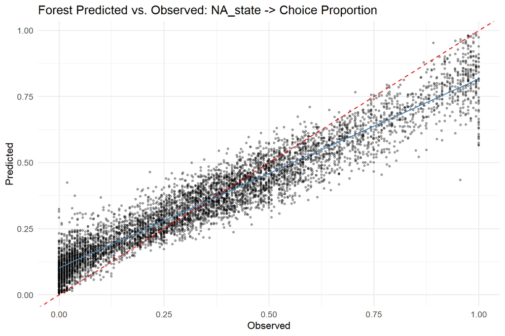

## 4.4 Model Comparison

### 4.4.1 RMSE Comparison (all methods and feature sets)

| Method | Raw | PCA | UMAP |
| --- | --- | --- | --- |
| glmm | 0.2885 | 0.3070 | 0.2814 |
| forest | 0.1919 | 0.2335 | 0.2132 |
| tree | 0.2457 | 0.2618 | 0.2677 |

# 5 Positive Affect State (PA_state)

## 5.1 Dimensionality Reduction

- **PCA components (80% variance, max 5):** 5
- **UMAP components (matching PCA):** 5

### 5.1.1 PCA Component Composition (top 5 correlated variables)

**PC_1**

| Variable | Correlation |
| --- | --- |
| alc_exp_energeticYes | -0.576 |
| alc_exp_better_moodYes | -0.557 |
| alc_exp_sociableYes | -0.547 |
| alc_exp_buzzYes | -0.502 |
| alc_craving | -0.487 |

**PC_2**

| Variable | Correlation |
| --- | --- |
| alc_exp_injuryYes | -0.595 |
| alc_exp_be_rudeYes | -0.593 |
| alc_exp_embarrassedYes | -0.578 |
| alc_exp_nauseous_vomitYes | -0.491 |
| alc_exp_hangoverYes | -0.467 |

**PC_3**

| Variable | Correlation |
| --- | --- |
| locationschool_work | 0.590 |
| alc_today | -0.578 |
| alc_cuenone | 0.569 |
| time_of_dayevening | -0.476 |
| locationhome | -0.456 |

**PC_4**

| Variable | Correlation |
| --- | --- |
| soft_yday | 0.698 |
| soft_today | 0.649 |
| soft_intend | 0.633 |
| soft_craving | 0.489 |
| alc_exp_embarrassedYes | -0.389 |

**PC_5**

| Variable | Correlation |
| --- | --- |
| locationhome | -0.634 |
| social_context_aloneYes | -0.558 |
| social_context_friend_roommateYes | 0.500 |
| social_context_strangerYes | 0.417 |
| locationsomeone_elses_home | 0.371 |

### 5.1.2 UMAP Component Composition (top 5 correlated variables)

**UMAP_1**

| Variable | Correlation |
| --- | --- |
| alc_exp_embarrassedYes | 0.275 |
| alc_exp_be_rudeYes | 0.271 |
| alc_craving | 0.231 |
| alc_intend | 0.221 |
| alc_yday | 0.195 |

**UMAP_2**

| Variable | Correlation |
| --- | --- |
| alc_yday | -0.270 |
| alc_exp_embarrassedYes | 0.197 |
| alc_exp_be_rudeYes | 0.194 |
| soft_yday | 0.121 |
| alc_mot_enhanceYes | -0.112 |

**UMAP_3**

| Variable | Correlation |
| --- | --- |
| alc_yday | -0.474 |
| alc_today | -0.440 |
| alc_intend | -0.199 |
| alc_cuenone | 0.199 |
| social_context_familyYes | -0.133 |

**UMAP_4**

| Variable | Correlation |
| --- | --- |
| soft_yday | 0.817 |
| soft_today | 0.709 |
| soft_intend | 0.586 |
| soft_craving | 0.315 |
| alc_exp_be_rudeYes | 0.168 |

**UMAP_5**

| Variable | Correlation |
| --- | --- |
| alc_exp_injuryYes | 0.515 |
| alc_exp_embarrassedYes | 0.383 |
| alc_exp_be_rudeYes | 0.381 |
| alc_exp_nauseous_vomitYes | 0.358 |
| alc_exp_energeticYes | 0.232 |

## 5.2 GLMM Results

### 5.2.1 Raw Features

- **Optimal lambda:** 75 (index 6 of 21)
- **CV RMSE:** 0.2928

**Non-zero coefficients** (focal predictor terms highlighted):

| Term | Estimate | Category |
| --- | --- | --- |
| (Intercept) | 0.2793 | Intercept |
| PA_state | -0.0022 | Focal predictor |
| alc_exp_nauseous_vomitYes | -0.0384 | Covariate main effect |
| alc_craving | 0.0327 | Covariate main effect |
| alc_exp_relaxedYes | 0.0277 | Covariate main effect |
| alc_cuenone | -0.0259 | Covariate main effect |
| alc_mot_enhanceYes | 0.0156 | Covariate main effect |
| alc_exp_better_moodYes | 0.0144 | Covariate main effect |
| time_of_dayevening | 0.0142 | Covariate main effect |
| alc_intend | 0.0119 | Covariate main effect |
| alc_exp_buzzYes | 0.0111 | Covariate main effect |
| alc_today | 0.0072 | Covariate main effect |
| soft_intend | -0.0063 | Covariate main effect |
| soft_craving | -0.0058 | Covariate main effect |
| alc_mot_copingYes | 0.0051 | Covariate main effect |
| social_context_familyYes | -0.0032 | Covariate main effect |
| social_context_romantic_partnerYes | 0.0029 | Covariate main effect |
| alc_yday | 0.0019 | Covariate main effect |
| soft_yday | -0.0015 | Covariate main effect |
| alc_exp_be_rudeYes | -0.0012 | Covariate main effect |
| social_context_strangerYes | 0.0012 | Covariate main effect |
| alc_exp_injuryYes | -0.0010 | Covariate main effect |
| locationother | 0.0010 | Covariate main effect |
| bored_state | 0.0008 | Covariate main effect |
| alc_exp_energeticYes | -0.0007 | Covariate main effect |
| alc_exp_hangoverYes | -0.0006 | Covariate main effect |
| thirst_state | 0.0003 | Covariate main effect |
| alc_exp_sociableYes | 0.0002 | Covariate main effect |
| hunger_state | -0.0001 | Covariate main effect |
| alc_exp_nauseous_vomitYes:PA_state | -0.0118 | Interaction with focal predictor |
| alc_cuenone:PA_state | -0.0099 | Interaction with focal predictor |
| alc_craving:PA_state | 0.0092 | Interaction with focal predictor |
| time_of_dayevening:PA_state | 0.0060 | Interaction with focal predictor |
| alc_exp_relaxedYes:PA_state | 0.0034 | Interaction with focal predictor |
| alc_intend:PA_state | 0.0028 | Interaction with focal predictor |
| soft_intend:PA_state | -0.0021 | Interaction with focal predictor |
| soft_craving:PA_state | -0.0020 | Interaction with focal predictor |
| alc_today:PA_state | 0.0016 | Interaction with focal predictor |
| locationhome:PA_state | -0.0016 | Interaction with focal predictor |
| alc_mot_enhanceYes:PA_state | 0.0015 | Interaction with focal predictor |
| social_context_familyYes:PA_state | -0.0015 | Interaction with focal predictor |
| alc_exp_hangoverYes:PA_state | -0.0012 | Interaction with focal predictor |
| alc_exp_injuryYes:PA_state | -0.0008 | Interaction with focal predictor |
| soft_yday:PA_state | -0.0006 | Interaction with focal predictor |
| alc_exp_sociableYes:PA_state | -0.0004 | Interaction with focal predictor |
| social_context_romantic_partnerYes:PA_state | 0.0004 | Interaction with focal predictor |
| social_context_friend_roommateYes:PA_state | -0.0003 | Interaction with focal predictor |
| alc_exp_energeticYes:PA_state | -0.0002 | Interaction with focal predictor |
| alc_exp_be_rudeYes:PA_state | -0.0002 | Interaction with focal predictor |
| alc_mot_copingYes:PA_state | -0.0002 | Interaction with focal predictor |
| alc_exp_buzzYes:PA_state | 0.0001 | Interaction with focal predictor |
| alc_mot_socialYes:PA_state | -0.0001 | Interaction with focal predictor |
| social_context_aloneYes:PA_state | -0.0001 | Interaction with focal predictor |
| responsibilityYes:PA_state | 0.0001 | Interaction with focal predictor |

- 44 coefficients penalized to zero.*

#### 5.2.1.1 Predicted vs. Observed

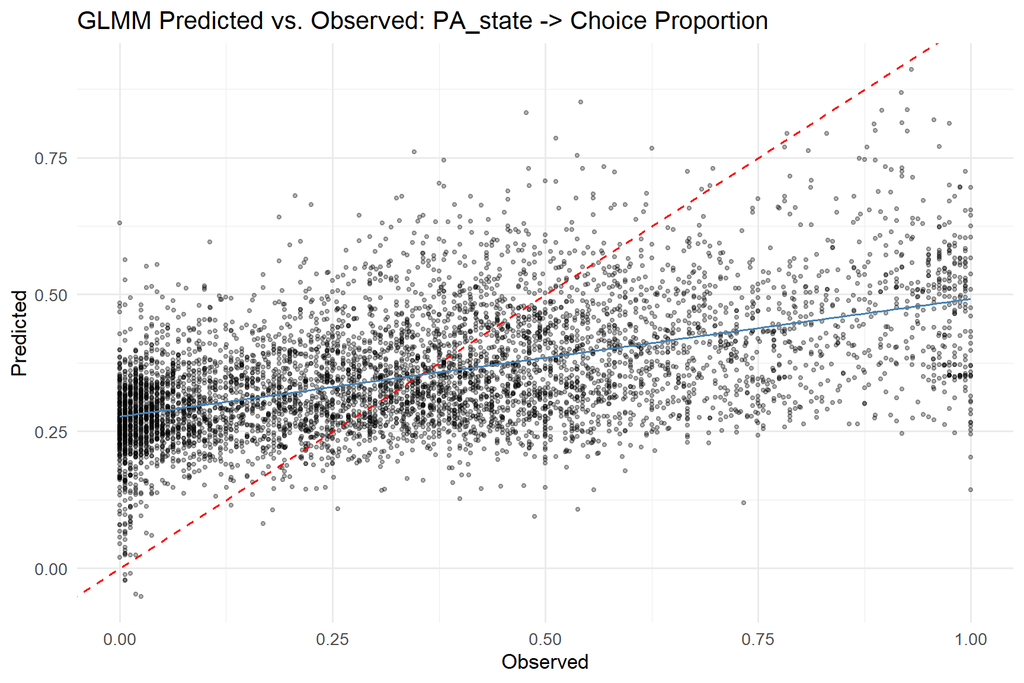

#### 5.2.1.2 Residual Diagnostics

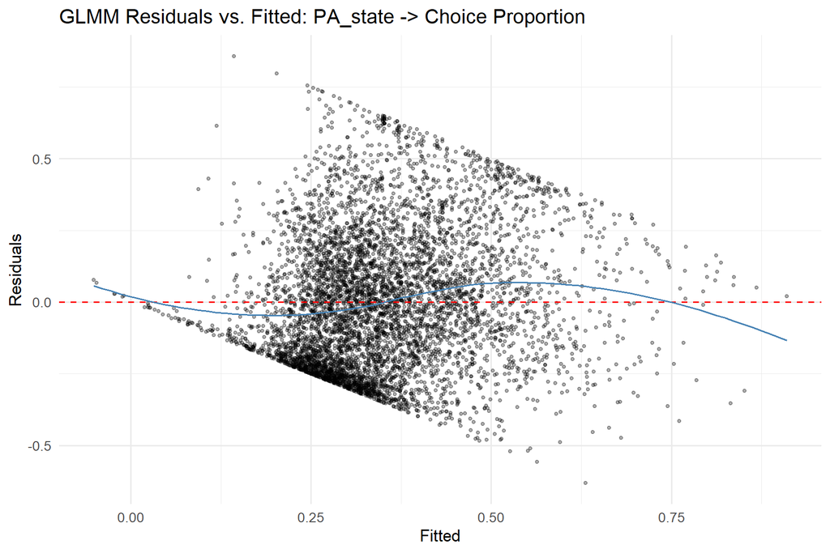

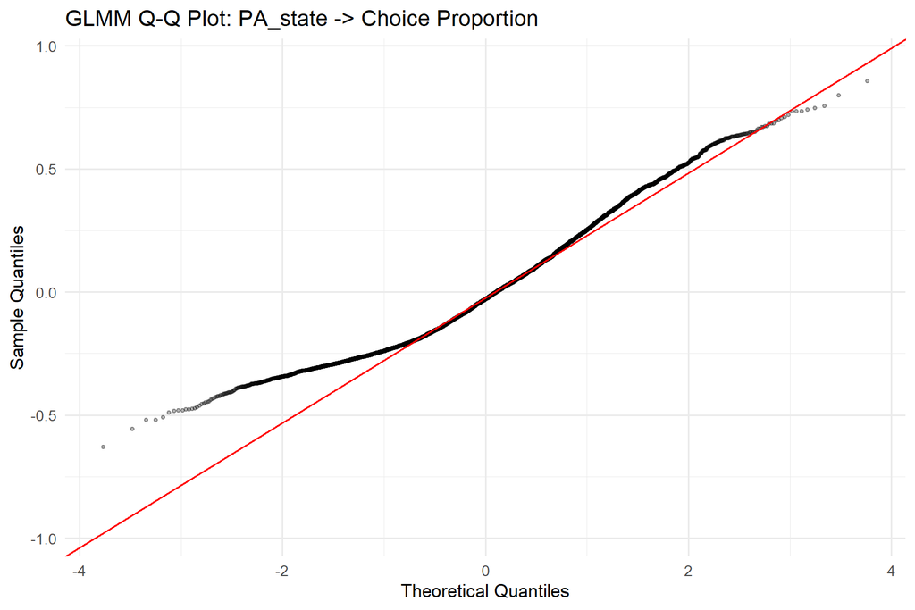

### 5.2.2 PCA Features

- **Optimal lambda:** 80 (index 5 of 21)
- **CV RMSE:** 0.2971

**Non-zero coefficients:**

| Term | Estimate |
| --- | --- |
| (Intercept) | 0.3604 |
| PC_1 | -0.0333 |
| PC_2 | 0.0581 |
| PC_3 | -0.0437 |
| PC_5 | -0.0049 |
| PA_state | -0.0033 |
| PC_2:PA_state | 0.0041 |
| PC_3:PA_state | -0.0059 |
| PC_5:PA_state | -0.0070 |

- 3 coefficients penalized to zero.*

### 5.2.3 UMAP Features

- **Optimal lambda:** 95 (index 2 of 21)
- **CV RMSE:** 0.2754

**Non-zero coefficients:**

| Term | Estimate |
| --- | --- |
| (Intercept) | 0.3531 |
| UMAP_2 | -0.0047 |
| UMAP_3 | -0.0171 |
| UMAP_4 | -0.0203 |
| UMAP_1:PA_state | 0.0063 |
| UMAP_2:PA_state | -0.0001 |
| UMAP_3:PA_state | -0.0024 |
| UMAP_4:PA_state | -0.0012 |
| UMAP_5:PA_state | 0.0004 |

- 3 coefficients penalized to zero.*

## 5.3 Random Forest Results (Raw)

### 5.3.1 Tuning Summary

- **mtry:** 12
- **min.node.size:** 2
- **sample.fraction:** 0.852
- **CV RMSE:** 0.1919

### 5.3.2 Variable Importance (Permutation)

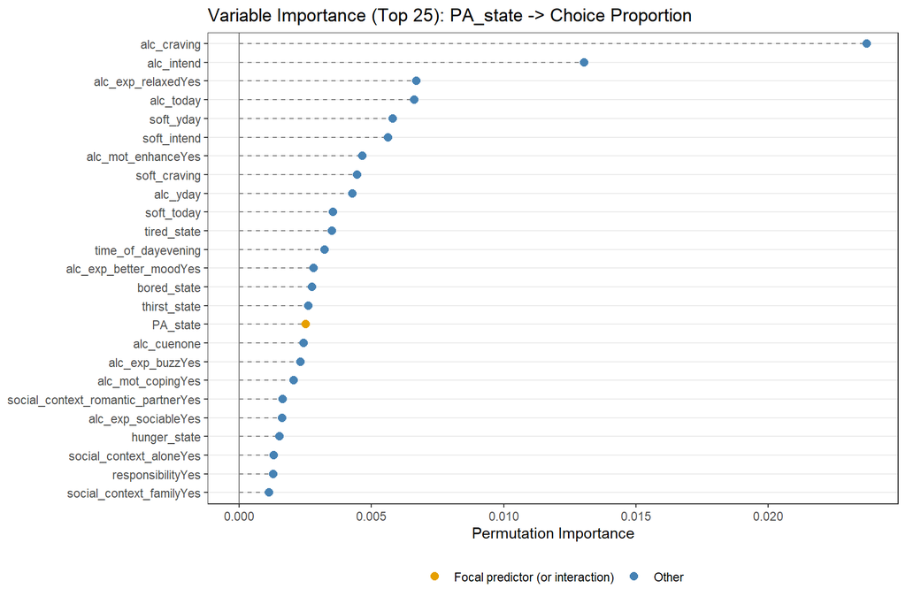

**Full importance ranking:**

| Variable | Importance |
| --- | --- |
| alc_craving | 0.023722 |
| alc_intend | 0.013043 |
| alc_exp_relaxedYes | 0.006690 |
| alc_today | 0.006617 |
| soft_yday | 0.005801 |
| soft_intend | 0.005619 |
| alc_mot_enhanceYes | 0.004659 |
| soft_craving | 0.004448 |
| alc_yday | 0.004284 |
| soft_today | 0.003546 |
| tired_state | 0.003501 |
| time_of_dayevening | 0.003225 |
| alc_exp_better_moodYes | 0.002816 |
| bored_state | 0.002760 |
| thirst_state | 0.002605 |
| PA_state | 0.002524 |
| alc_cuenone | 0.002426 |
| alc_exp_buzzYes | 0.002324 |
| alc_mot_copingYes | 0.002056 |
| social_context_romantic_partnerYes | 0.001636 |
| alc_exp_sociableYes | 0.001623 |
| hunger_state | 0.001525 |
| social_context_aloneYes | 0.001301 |
| responsibilityYes | 0.001277 |
| social_context_familyYes | 0.001127 |
| alc_exp_hangoverYes | 0.000797 |
| alc_exp_embarrassedYes | 0.000770 |
| locationhome | 0.000719 |
| alc_exp_energeticYes | 0.000575 |
| locationschool_work | 0.000573 |
| alc_exp_nauseous_vomitYes | 0.000563 |
| alc_exp_be_rudeYes | 0.000476 |
| alc_mot_socialYes | 0.000398 |
| alc_exp_injuryYes | 0.000281 |
| locationother | 0.000190 |
| social_context_friend_roommateYes | 0.000121 |
| alc_cueindirectly_visible | 0.000060 |
| locationsomeone_elses_home | 0.000057 |
| day_of_weekSun | 0.000048 |
| social_context_strangerYes | 0.000046 |
| locationoutdoors | 0.000039 |
| day_of_weekSat | 0.000035 |
| social_context_coworker_classmateYes | 0.000029 |
| locationrestaurant_cafe | 0.000014 |
| social_context_otherYes | 0.000013 |
| day_of_weekThu | -0.000057 |
| day_of_weekWed | -0.000069 |
| day_of_weekMon | -0.000103 |
| day_of_weekTue | -0.000106 |

### 5.3.3 Partial Dependence Plots

PDP for the focal predictor and the top 5 most important non-interaction covariates.

#### 5.3.3.1 Focal Predictor: PA_state

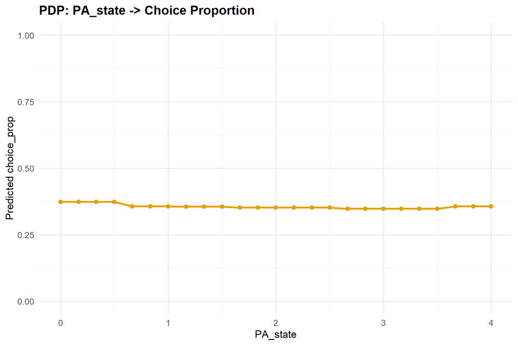

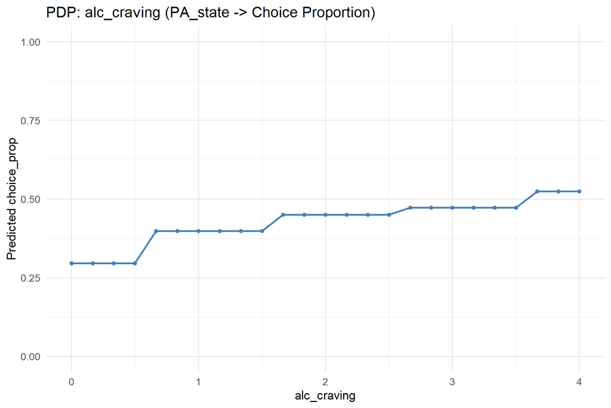

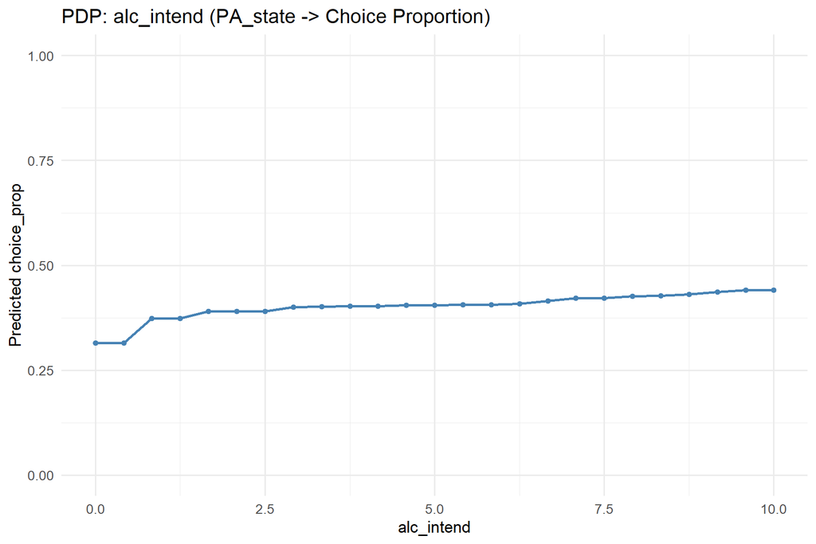

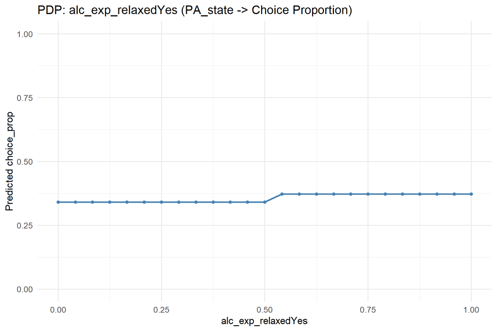

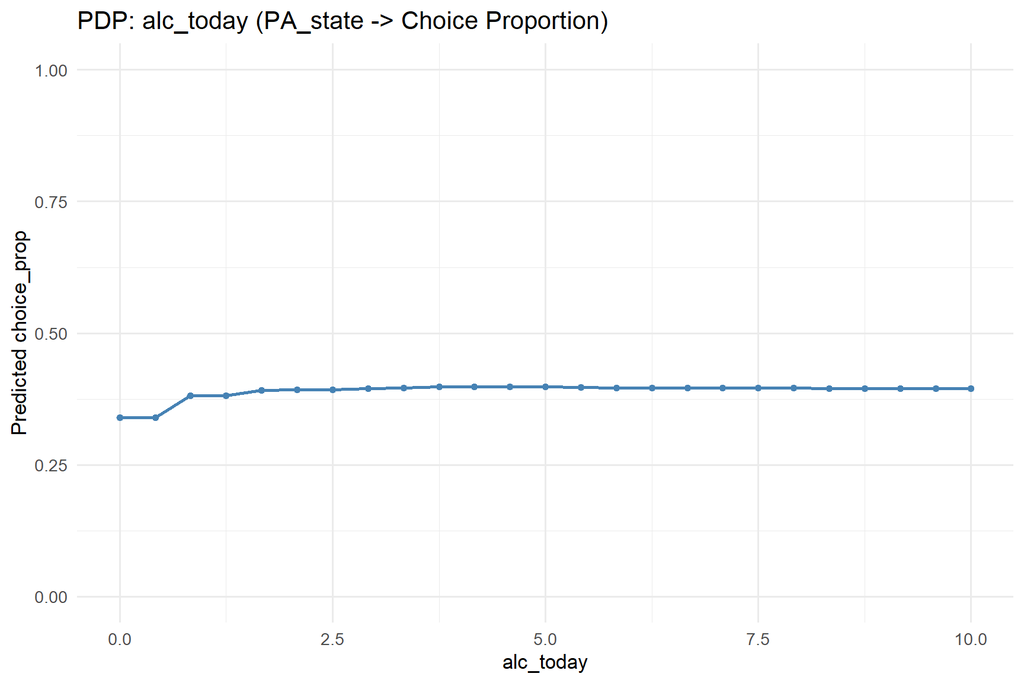

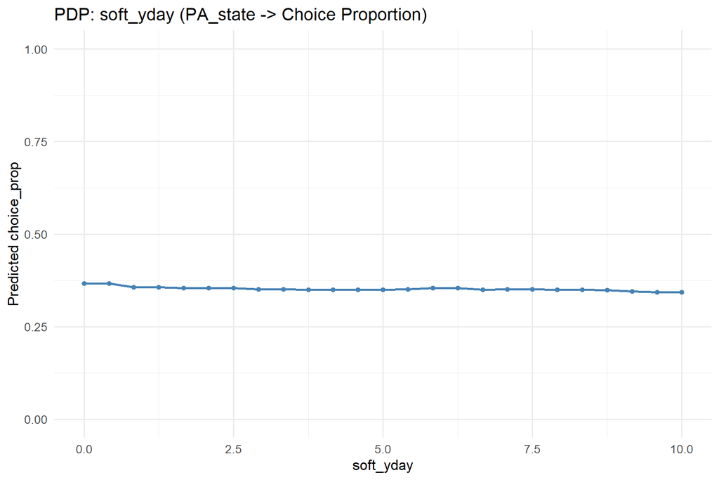

### 5.3.4 Predicted vs. Observed

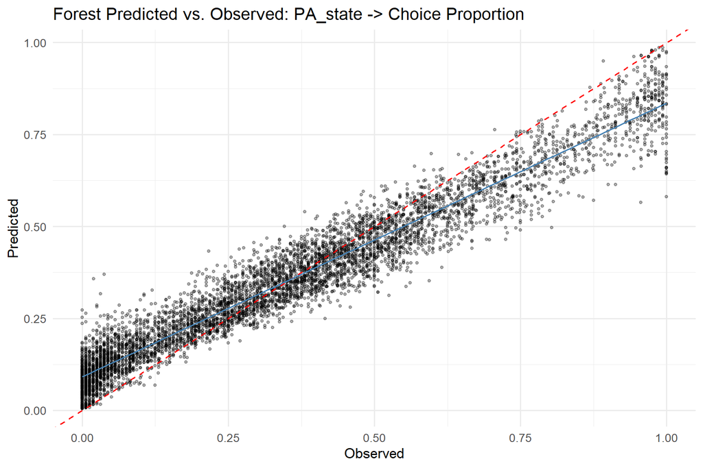

## 5.4 Model Comparison

### 5.4.1 RMSE Comparison (all methods and feature sets)

| Method | Raw | PCA | UMAP |
| --- | --- | --- | --- |
| glmm | 0.2928 | 0.2971 | 0.2754 |
| forest | 0.1919 | 0.2331 | 0.2136 |
| tree | 0.2465 | 0.2617 | 0.2662 |